# Assesing Default Risk Among Loan Applicants Without Credit History

Ray Saitoti & Gabriel Young

9/8/2019

## Abstract

The experiment uses data from the Home Credit Company and attempts to ascertain whether or not borrowers from the group are trustworthy enough to repay their loans using metrics other than the commonly accepted “credit score”. The experiment consists of an exploratory factor analysis, a k-nearest neighbor classification model, and a logistic neural net. The experimenters found no sufficient factor solution from the EFA, and that the k-nearest neighbor model attained a high degree of accuracy for classifying new borrowers based on its training data. The neural net achieves similar accuracy to the k nearest neighbor model. The experimenters conclude that it is possible to classify borrowers as trustworthy or not by the metrics used but that recovery of latent variables relating to trustworthiness requires more information to be considered.

## Introduction

Lending money is a profitable enterprise but only if you’re loaning to people that pay back their loans. Therefore, it is very important for banks and companies to be able to assess beforehand whether or not a person is likely to repay a loan. Many criteria have been considered over the years in attempts to gauge the responsibility of a borrower including but not limited to the borrower’s previous loan history, the area in which they are living, and how long it has been since they changed phone numbers. One of the key metrics used in the credit history, a measure of how you have behaved with previous loans calculated from how much you borrow, how often you make late payments, and how often you default. Most lending entities today prioritize credit history as their metric of choice when considering loan applications and often will not loan to applicants who cannot present a satisfactory credit history.

However, this leads to a problem for both the loaners and the borrowers: the borrowers cannot get the capital they might need without submitting to terrible loan deals and the loaners leave a large population of customers untapped. Our group’s analysis seeks to bridge this gap somewhat by analyzing nonstandard metrics other than credit history to predict the trustworthiness of a borrower. We reasoned that an accurate classification model could provide the loan entities with some assurance that their loans will be repaid and that, with less risk, they would be more willing to loan to this non borrowing population, benefiting everyone.

We attempt to address this issue by means of an initial exploratory factor analysis (EFA) in which we will try to recover latent variables relating to clients’ trustworthiness. The hope is that such observations will be informative to future attempts at classification and in the compiling of other data sets, in other words, by finding which variables in our data set are most informative, companies and researchers can prioritize them both at the data collection stage and at the evaluation stage.

After this we plan to apply k-nearest neighbours classifier to the data and form a predictive model for us on new data. This model, if accurate, would be a major deliverable of the project and ready for use by loan entities. At the very least this attempt at classification will inform us as to whether or not the quantitative variables being collected and used are informative to the question we are trying to answer.

Finally we will apply a logistic neural net with the same rationale as the k-nearest neighbor model. We chose it because we were interested in seeing whether we could do a better job in predicting whether or not a client would default on a loan. A neural net is a platform for many machine learning techniques. A system of neuron nodes are set up each with a different random weight and connected to a random selection of the input variables. The process runs on the training set to classify the data and then adjusts the weights of its neurons based on the most erroneous cases, repeating until the weights of the neurons are no longer adjusting or until some other specified cutoff point is reached. By using both these classification methods we will be able to compare the two models and either confirm the accuracy or our predictions or indicate more work is needed on one model or the other.

## Data

Our data comes from the Home Credit Company which is interested in giving loans to clients that have no credit history. As such, other metrics must be used and the challenge of this dataset is evaluating a borrower’s likelihood of repaying from these other criteria. The 307511 observation dataset of loans contains 122 alternative variables and is not terribly tidy, so we do some work on the dataset before working with it.

Target: binary indicator of default, 0 is no default, 1 is default.

Income: annual income of the borrower

Loan amount: the dollar amount of the requested loan

Loan annuity: how much collateral the borrower could present

Region Population: the normalized level of population for that area

Client Age: age in years

Length of Employment: negative values indicate unemployment

Number of Family Members

Days Since Last Phone Change

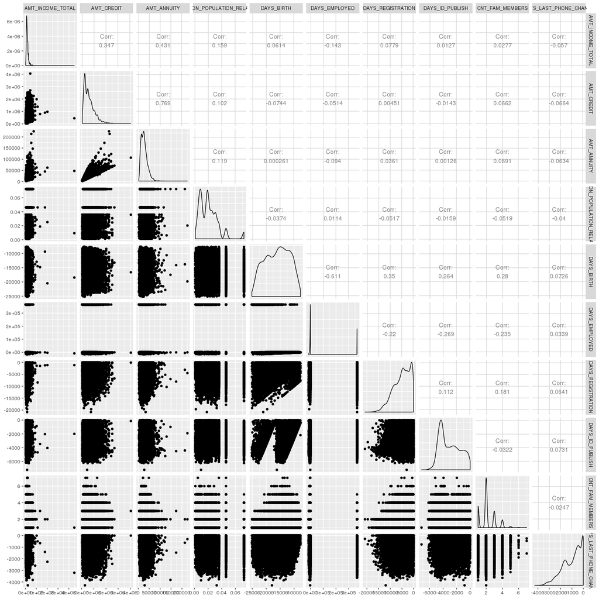

Correlation matrix showing variable distributions and correlations

## Methods

### 1. Factor Analysis

We deemed factor analysis to be more appropriate in our analysis than Principal Components Analysis because we were interested in which latent indicators of trustworthiness / ability to pay back loans could be recovered from our set of manifest variables. We used the maximum likelihood approach so that we could determine, through repeated hypothesis testing, which number of factors was most appropriate.

### 2. Classification

#### K Nearest Neighbors:

The first classification method we used was a KNN classifier. We explored the efficacy of 10 different values of k (1-10) and made a plot to see how both the apparent error rate and the estimated true error rate behaved for the various values of k. An 80% ~ 20% holdout sample approach was also used here for the train and test set respectively.

#### Neural nets:

The second classification method used was neural nets. Neural nets are composed of layers of weighted neurons that pass on 0 or 1 depending on whether the weighted sums of their inputs exceed their activation potential. The system is modeled after the function of the neurons in the human brain. By working on the training set iteratively, the weights of the neurons can be refined based on the misclassifications until all training samples are classified (or, to reduce over fitting, until a certain number of iterations have been reached). By layering these sets of neurons and having the outputs of one layer be fed into the next, you can do this weight-refining approach several times and achieve accuracy in complex classifications far beyond the scope of regression, as evidenced by their use in photo analysis, voice identification, and of course in our own heads.

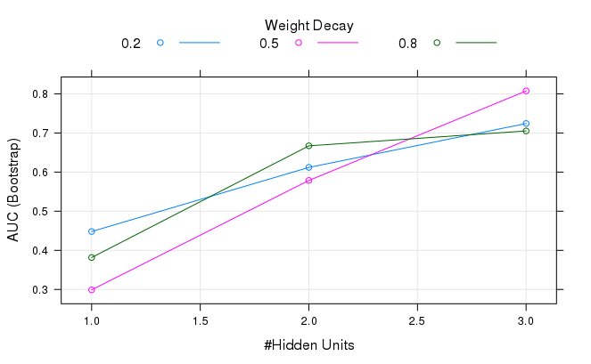

Model performance for different parameter combinations

## Results

### Factor Analysis:

We examined the solutions corresponding to the five possible factor solutions to find the one with the most compelling interpretation. Although the p-values yielded from the maximum likelihood evaluation of the five factor solution suggested that none of them could adequately account for the variations in the data, our factors in the five factor model did satisfy the principles of Thurstone’s simple structure. The first factor in this model loads highly on credit and annuity thus it could be labelled non-Income assets. The second one is a contrast between age and duration of employment. The third is dominated by continuous family members therefore it could be seen as a measure of client mobility. The fourth reflects income whereas the fifth seems like a weighted average.

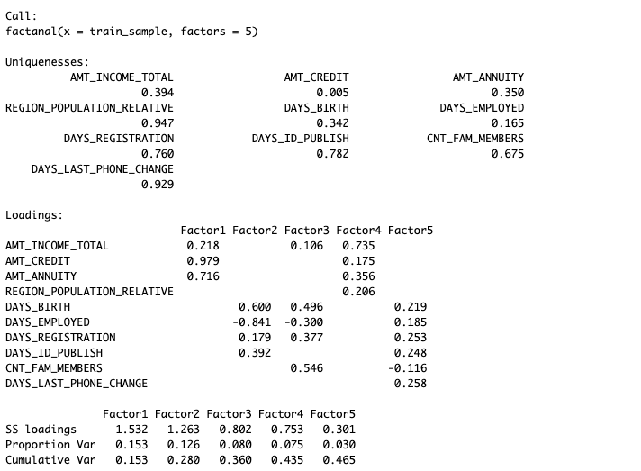

### K Nearest Neighbors:

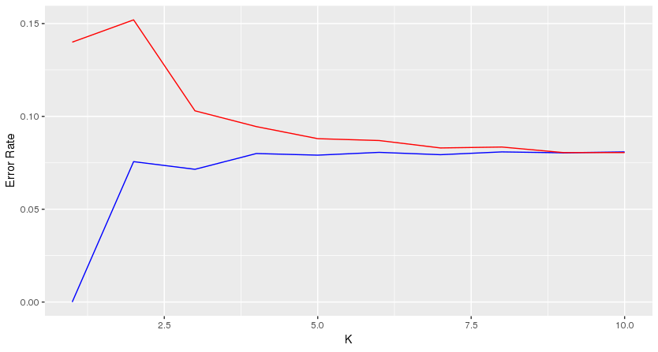

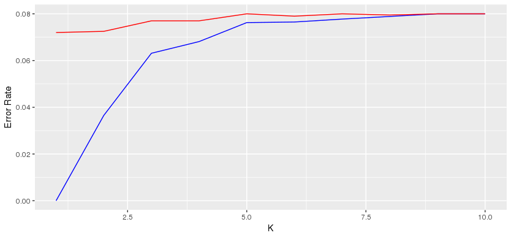

Figure1 is the graph of the AER and TER for the KNN runs on values of K from 1:10. We are performing fairly well for larger values of k and additionally we see a convergence toward a 0.08 error rate in both the AER and the TER. However, due to the nature of our data, we shouldn’t treat all error rates equally. From the viewpoint of the company, mistakenly classifying a paying borrower as nonpaying is less harmful than classifying a nonpaying borrower as paying. In other words, a false positive from our classifier means we give a loan that is not paid back. Let’s consider the error rate of only these harmful errors in Figure2.

## Citations

1. Brownlee, Jason. “Tuning Machine Learning Models Using the Caret R Package.” Machine Learning Mastery, 22 Sept. 2016, www.machinelearningmastery.com/tuning-machine-learning-models-using-the-caret-r-package/.
2. Portilla, Jose. “KDnuggets.” KDnuggets Analytics Big Data Data Mining and Data Science, 2016, www.kdnuggets.com/2016/08/begineers-guide-neural-networks-r.html.
3. “Weight Decay in Neural Networks.” Metacademy, metacademy.org/graphs/concepts/weight_decay_neural_networks.
4. R documentation caret package
5. Multivariate Analysis With R